# Single-Cell RNA Sequencing Analysis

Huijian Feng

July 29th, 2019

## 1. Introduction

This tutorial provides an approach to basic analysis for single-cell RNA sequencing data:

1. Data pre-processing
- QC and selecting cells
- Normalizing the data
- Identifying high variable genes(feature selection)
- Scaling the data
2. Linear dimensional reduction
- PCA
- Determine dimensionality of PCs
3. Cluster the cells
4. Visualization
5. Differentially expressed genes
6. Identify the cell types
7. Enrichment analysis
- Gene Ontology
- Pathway Enrichment

This tutorial refers to [Seurat](https://satijalab.org/seurat/v3.0/pbmc3k_tutorial.html), a software(package) for analyzing single-cell RNA seq data in `R`.

Feel free to contact me if you have any questions.  
Email: feng_huijian@gibh.ac.cn  
Wechat: rick__sanchez__

## 2. Preparation

### 2.1 Software

All the anaylsis below relies on the `R` environment. Please download R and related software before the coures.

We select the tsinghua mirror to download R

1. Download and install [R](https://mirrors.tuna.tsinghua.edu.cn/CRAN/)
- Windows user: Please click `Download R for Windows`, and then click `install R for the first time`.
- Mac user: Please click `Download R for (Mac) OS X`, and then click `R-3.6.1.pkg`.
2. Download and install [Rstudio](https://www.rstudio.com/products/rstudio/download/), and then select `RStudio Desktop Open Source License FREE` to download Windows Version `RStudio 1.2.1335 - Windows 7+ (64-bit)` or Mac Version `RStudio 1.2.1335 - Mac OS X 10.12+ (64-bit)`
3. Install the R packages for the following analysis.

   We also use the **tsinghua mirror** to download R packages for saving times and avoiding the unnecessary `Error`. Open the areadly installed **Rstudio**. Paste and execute the code below in the **Console panel**:

   ```r
   # rcran
   options("repos" = c(CRAN="https://mirrors.tuna.tsinghua.edu.cn/CRAN/"))

   # install bioconductor library.
   options("repos" = c(CRAN="https://mirrors.tuna.tsinghua.edu.cn/CRAN/"))
   if (!requireNamespace("BiocManager"))
     install.packages("BiocManager")
   # bioconductor
   options(useHTTPS=FALSE, BioC_mirror="http://mirrors.tuna.tsinghua.edu.cn/bioconductor/")

   # A function: intalling the packages to R ->IPR
   IPR <- function(packages,
                   sources = c("RCran", "Bioconductor", "Github")){
     installedpackages <- installed.packages()[ ,"Package"]
     existpackages <- intersect(packages, installedpackages)
     if(length(existpackages) != 0){
       print(paste0("Packages ", existpackages, " have been installed"))
       }
     newpackages <- setdiff(packages, installedpackages)
     if(length(newpackages) != 0){
       if(sources == "RCran"){
         install.packages(newpackages)
         }
       if(sources == "Bioconductor"){
         BiocManager::install(newpackages)
         }
       if(sources == "Github"){
         devtools::install_github(newpackages)
         }
       }
   }

   # R CRAN packages
   # rpkg <- c("dplyr","ggplot2","matrixStats","pheatmap","DT","data.table", "Seurat")
   # IPR(packages = rpkg, sources = "RCran")

   # Bioconductor packages
   # biopkg <- c("clusterProfiler", "org.Mm.eg.db", "org.Hs.eg.db", "genefilter", "ReactomePA")
   # IPR(packages = biopkg, sources = "Bioconductor")
   ```

### 2.2 Data

1. Open 10X official website for [downloading data](https://www.10xgenomics.com/10x-university/single-cell/).
2. Select section `DATASETS` and click `View all`
3. When you enter this page, you should fill in the relevant information: `Name`, `Your Email`, `Institution`, `Country`. Click `no` for “receive update” and agree the “Privacy Policy”.
4. Select `3k PBMCs from a Healthy Donor`. And then select `Gene / cell matrix (filtered)`. **Warning:** This Object size is 7.27 MB.

And then you should extract the compressed file into a directory, such as `D:/singlecell_pratice`(this directory need to be created).

Then, we can check how the 10X single-cell RNA seq data is stored. we open the directory`D:/singlecell_pratice/pbmc3k_filtered_gene_bc_matrices/filtered_gene_bc_matrices/hg19`, and we will find that three compressed files store their respective files:

- `barcodes.tsv` is used to store the information of each **cell barcode**. In general, it store the name of each single-cell.
- `genes.tsv` is used to store the **genetic information** obtained by sequencing.
- `matrix.mtx` is used to store the **data of single-cell expressed genes**, and it is a storage format for sparse matrices using the Coordinate Format([COO](http://scc.ustc.edu.cn/zlsc/sugon/intel/mkl/mkl_manual/GUID-9FCEB1C4-670D-4738-81D2-F378013412B0.htm) If you are interested in this format, click it.)

## 3. Strat

### 3.1 Load Packages

We load the packages by calling `library()` at firt.

```r
library(Seurat)
library(dplyr)
library(ggplot2)
library(RColorBrewer)
library(cowplot)
library(clusterProfiler)
library(genefilter)
library(ReactomePA)
library(DT)
```

### 3.2 Setup the Seurat Object

At first, We have to set a correct working directory.

Then we can load the data by calling `Read10X()`. This function can read the three files(`barcodes.tsv`, `genes.tsv`, `matrix.mtx`) in the directory at once.

Then we can setup the **seurat object** by calling `CreateSeuratObject()`.

We highly encourage querying the detail of a function by calling `help(function_name)` or`?function_name`, such as `help(CreateSeuratObject)`.

```r
## Example for set working directory
## setwd("D:/singlecell_pratice")

## loading the data
pbmc <- Read10X("./pbmc3k_filtered_gene_bc_matrices/filtered_gene_bc_matrices/hg19")

## create the seurat object
pbmc <- CreateSeuratObject(counts = pbmc,
                           project = "sc_tutorial",
                           min.cells = 3,
                           min.features = 200)
# parameter counts : input the "raws gene expression marix"
# parameter project : input the "name of our project"
# parameter min.cells : exclude some "genes" which are expressed in less than 3 cells
# parameter min.features : exclude some "cells" which are expressing less then 200 genes

## view the data
pbmc
```

```
## An object of class Seurat
## 13714 features across 2700 samples within 1 assay
## Active assay: RNA (13714 features)
```

## 4. Data pre-processing

These workflow represent the selection and filtration of cells based on QC metrics, data normalization and data scaling, and the detection of highly variable genes.

### 4.1 QC and selecting cells

Seurat provides simple QC metrics and allow you to filter cells based on user-defined criterion. A few [QC metrics](https://www.ncbi.nlm.nih.gov/pmc/articles/PMC4758103/) include commonly:

- The number of unique genes detected in each cell(each droplet):
  - Low-quality cells or empty droplets will often have very few gene
  - Cell doublets or multiplets may have an aberrantly high gene count
- The above assumptions also apply to the total number of molecules in each cell(each droplet).
- The percentage of reads that map to the mitochondrial genome
  - Low-quality or dying cells often exhibit extensive mitochondrial contamination

we call `PercentageFeatureSet` to caculate the percentage of mitochondrial genes. Mitochondrial genes are a set genes which can be captured by matching the prefix `MT-`.

```r
## caculate the percentage of mitochondrial genes
pbmc[["percent.mt"]] <- PercentageFeatureSet(pbmc,
                                             pattern = "^MT-")
# The [[ operator can add columns to object metadata. You can use "pbmc[[]]" to check object metadata.
# parameter pattern : match regular expression. "^MT-" means that the gene with prefix "MT-"

## function head() allow us to check the first 6 rows of data frame
head(pbmc[[]])
```

```
##                 orig.ident nCount_RNA nFeature_RNA percent.mt
## AAACATACAACCAC sc_tutorial       2419          779  3.0177759
## AAACATTGAGCTAC sc_tutorial       4903         1352  3.7935958
## AAACATTGATCAGC sc_tutorial       3147         1129  0.8897363
## AAACCGTGCTTCCG sc_tutorial       2639          960  1.7430845
## AAACCGTGTATGCG sc_tutorial        980          521  1.2244898
## AAACGCACTGGTAC sc_tutorial       2163          781  1.6643551
```

In this data, we visualize the QC metric and use these filter cells.

`nCount_RNA` means that the total number of reads per cells map to the genome.  
`nFeature_RNA` means that the total number of genes expressed per cell.  
`percent.mt` means that the percentage of mitochondrial genes per cell.

- we filter cells that have `nFeature_RNA` over 2500
- we filter cells that have `nFeature_RNA` less than 200
- we filter cells that have `percent.mt` over 5%

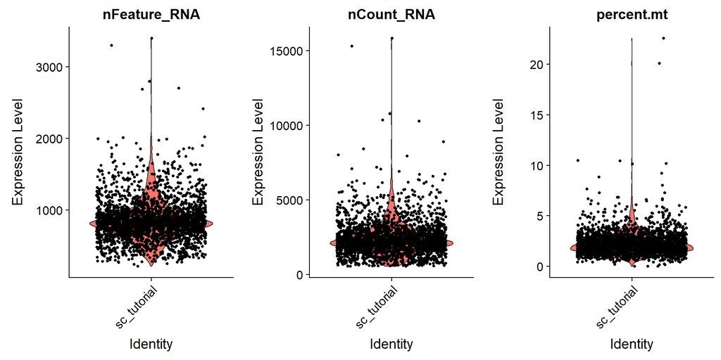

```r
## Check the distribution of the three QC metric
VlnPlot(pbmc,
        features = c("nFeature_RNA", "nCount_RNA", "percent.mt"),
        ncol = 3)
```

```r
## parameter
nfeature_min = 200
nfeature_max = 2500
percent_mt = 5
```

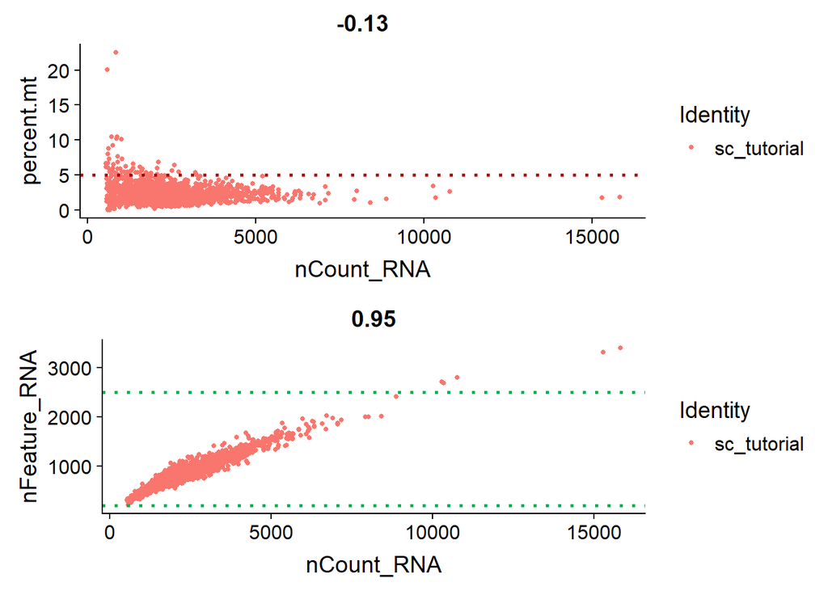

```r
## Check the distribution of the three QC metric
plot1 <- FeatureScatter(pbmc, feature1 = "nCount_RNA", feature2 = "percent.mt") +
  geom_hline(yintercept = percent_mt, linetype="dotted", size = 1, colour = "#ae0404")

plot2 <- FeatureScatter(pbmc, feature1 = "nCount_RNA", feature2 = "nFeature_RNA") +
  geom_hline(yintercept = nfeature_min, linetype="dotted", size = 1, colour = "#04ae59")+
  geom_hline(yintercept = nfeature_max, linetype="dotted", size = 1, colour = "#04ae59")
## plot
plot_grid(plot1, plot2, nrow = 2)
```

```r
## QC
# 200< nFeature_RNA < 2500 & percent.mt < 5%
pbmc <- subset(pbmc,
               subset = nFeature_RNA < nfeature_max & nFeature_RNA > nfeature_min & percent.mt < percent_mt)
## check data
pbmc
```

```
## An object of class Seurat
## 13714 features across 2638 samples within 1 assay
## Active assay: RNA (13714 features)
```

### 4.2 Normalizing the data

After moving unwanted cells, the next step is to normalize the data. We employ a global-scaling normalizaiton method `LogNormalize` that normalizes the feature expression measurements for each cell by the total expression, multiplies this by a `scale factor`(10,000 by default), and log-transforms the result. Normalized values are stored in the `pbmc[["RNA"]]@data` which is another sparse matrix.

```r
# normalizing data
pbmc <- NormalizeData(pbmc,
                      normalization.method = "LogNormalize",
                      scale.factor = 10000)
```

### 4.3 Identifying high variable genes

We next caculate a subset of geens that exhibit high cell-to-cell variation in the data(they are highly expressed in some cells,and lowly expressed in others). The [high varialble genes](https://www.nature.com/articles/nmeth.2645) can highlight biological signal in single-cell data. we can find high variable genes(HVGs) by calling `FindVariableFeature()` function. By default, we return **top 2000 HVGs** in single-cell data. These genes will be used in downstream analysis, like PCA. The resluts are stored in `pbmc[["RNA"]]@var.features`

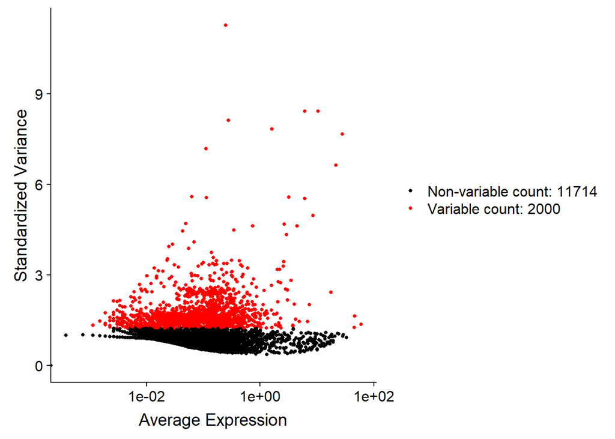

```r
##  caculates hvgs in single-cell data
pbmc <- FindVariableFeatures(pbmc,
                             selection.method = "vst",
                             nfeatures = 2000)
# "vst" is a method that model the mean-variance relationship in single-cell data.
# parameter nfeatures is to select top genes

## plot top 2000 HVGs
plot1 <- VariableFeaturePlot(pbmc)
plot1
```

### 4.4 Scaling the data

Next, we apply a linear transformation(“scaling”) that is a standard pre-processing step prior to dimensional reduction techniques like PCA. The `scaleData` function:

- Shift the expression of each gene, so that the mean expressiong across cells is 0
- Scales the expression of each gene, so that the variance across cells is 1 The results are stored in the `pbmc[["RNA"]]@scale.data`

```r
## select all genes to perform the scale function
allgenes <- rownames(pbmc)
pbmc <- ScaleData(pbmc,
                  features = allgenes)

# select top 2000 HVGs and perform the scale function
# top2000 <- pbmc[["RNA"]]@var.features
# pbmc <- ScaleData(pbmc, features = top2000)
```

**Brief summary**

In the data pre-processing workflow, we do

1. QC and selecting cells This step is to remove th low-quality or outlier cells.
2. Normalizing the data This step is to smooth gene expression, so that the highly-expressed genes are not “so high”
3. Identifying high variable genes(feature selection) This step is to highlight biological signal in single-cell data
4. Scaling the data This step gives equal weight in downstream analyses, so that highly-expressed genes do not dominate

## 5. Linear dimensional reduction

### 5.1 PCA

Next, we perform PCA on the `scale.data`. By default, only the previously detemined variable features are used as input. we select the top 2000 HVGs as input.

```r
## perform the PCA by input top2000 genes
top2000 <- pbmc[["RNA"]]@var.features
pbmc <- RunPCA(pbmc,
               features = top2000,
               npcs = 50,
               verbose = FALSE)
# parameter features to input user-defined genes
# parameter npcs, the number of PCA
```

### 5.2 Determine dimensionality of PCs

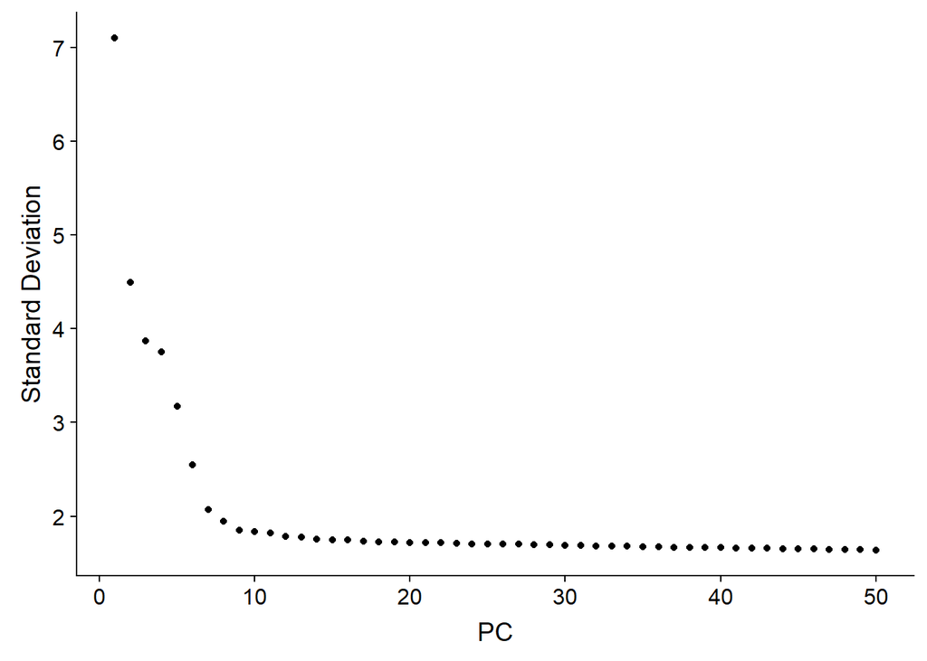

```r
# pbmc <- JackStraw(pbmc, num.replicate = 100, dims = 30)
ElbowPlot(pbmc, ndims = 50)
```

## 6. Cluster the cells

Seurat applies a graph-based clustering approach. 1. They first construct a KNN graph based on the Euclidean distance in PCA space, and refine the edge weights between any two cells based on the shared overlap in their local neighborhoods. Call `FindNeighbors()` to construct a KNN graph. 2. To cluster the cells, they apply the modularity optimization algorithm ( [Louvain algorithm](https://www.researchgate.net/publication/1913681_Fast_Unfolding_of_Communities_in_Large_Networks), default) to cluster the cells. We can call `FindClusters()` to do this step. And a parameter `resolution` is set in the `FindClusters()`, with increased values leading to a greater number of clusters.

```r
# selcet the first 10 PCs
pcs = 10
# create knn graph
pbmc <- FindNeighbors(pbmc,
                      dims = 1:pcs,
                      k.param = 20)
# louvain cluster
pbmc <- FindClusters(pbmc,
                     resolution = 0.5)
```

```
## Modularity Optimizer version 1.3.0 by Ludo Waltman and Nees Jan van Eck
##
## Number of nodes: 2638
## Number of edges: 96033
##
## Running Louvain algorithm...
## Maximum modularity in 10 random starts: 0.8720
## Number of communities: 9
## Elapsed time: 0 seconds
```

```r
# check the cluster labels
head(Idents(pbmc))
```

```
## AAACATACAACCAC AAACATTGAGCTAC AAACATTGATCAGC AAACCGTGCTTCCG AAACCGTGTATGCG
##              1              3              1              2              6
## AAACGCACTGGTAC
##              1
## Levels: 0 1 2 3 4 5 6 7 8
```

```r
# check the metadata
head(pbmc[[]])
```

```
##                 orig.ident nCount_RNA nFeature_RNA percent.mt
## AAACATACAACCAC sc_tutorial       2419          779  3.0177759
## AAACATTGAGCTAC sc_tutorial       4903         1352  3.7935958
## AAACATTGATCAGC sc_tutorial       3147         1129  0.8897363
## AAACCGTGCTTCCG sc_tutorial       2639          960  1.7430845
## AAACCGTGTATGCG sc_tutorial        980          521  1.2244898
## AAACGCACTGGTAC sc_tutorial       2163          781  1.6643551
##                RNA_snn_res.0.5 seurat_clusters
## AAACATACAACCAC               1               1
## AAACATTGAGCTAC               3               3
## AAACATTGATCAGC               1               1
## AAACCGTGCTTCCG               2               2
## AAACCGTGTATGCG               6               6
## AAACGCACTGGTAC               1               1
```

```r
# we should add user-defined annotation into the "metadata", such as "cell_labels"
# we can call pbmc$cell_labels, pbmc[[]]$cell_labels, or pbmc@assays$RNA@meta.features$cell_labels
pbmc$cell_labels <- as.character(as.numeric(pbmc$seurat_clusters))
# we modify the cluster labels
new_ident <- as.factor(as.numeric(pbmc$seurat_clusters))
names(new_ident) <- rownames(pbmc[[]])
Idents(pbmc) <- new_ident

# check the new cluster labels
head(Idents(pbmc))
```

```
## AAACATACAACCAC AAACATTGAGCTAC AAACATTGATCAGC AAACCGTGCTTCCG AAACCGTGTATGCG
##              2              4              2              3              7
## AAACGCACTGGTAC
##              2
## Levels: 1 2 3 4 5 6 7 8 9
```

```r
# cheack the new metadata
head(pbmc[[]])
```

```
##                 orig.ident nCount_RNA nFeature_RNA percent.mt
## AAACATACAACCAC sc_tutorial       2419          779  3.0177759
## AAACATTGAGCTAC sc_tutorial       4903         1352  3.7935958
## AAACATTGATCAGC sc_tutorial       3147         1129  0.8897363
## AAACCGTGCTTCCG sc_tutorial       2639          960  1.7430845
## AAACCGTGTATGCG sc_tutorial        980          521  1.2244898
## AAACGCACTGGTAC sc_tutorial       2163          781  1.6643551
##                RNA_snn_res.0.5 seurat_clusters cell_labels
## AAACATACAACCAC               1               1           2
## AAACATTGAGCTAC               3               3           4
## AAACATTGATCAGC               1               1           2
## AAACCGTGCTTCCG               2               2           3
## AAACCGTGTATGCG               6               6           7
## AAACGCACTGGTAC               1               1           2
```

## 7. Visualization

Seurat offers several **non-linear dimensional reduction techniques**, such as tSNE and UMAP, to visualize and explore these datasets. The goal of these algorithms is to learn the underlying manifold of the data in order to place similar cells together in low-dimensional space.

### call function `RunUMAP`.

If you haven’t installed UMAP, you can do so via `reticulate::py_install(packages = 'umap-learn')`

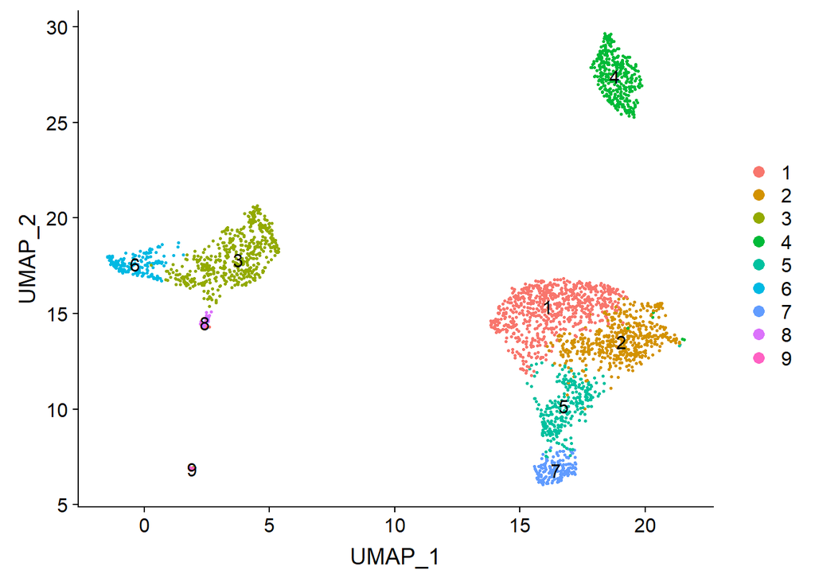

```r
# UMAP
pbmc <- RunUMAP(pbmc,
                dims = 1:pcs)
# individual clusters
DimPlot(pbmc,
        reduction = "umap",
        label = TRUE)
```

### call function `RunTSNE`.

If reticulate::py_install(packages = ‘umap-learn’) still don’t work, Please call this functioin

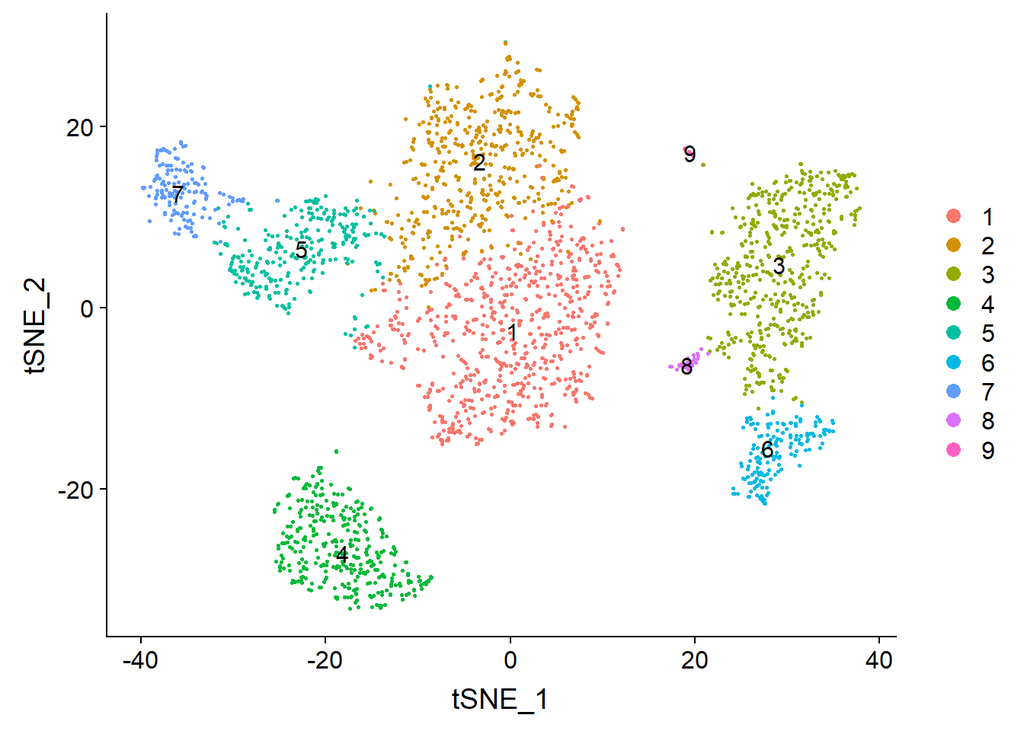

```r
# TSNE
pbmc <- RunTSNE(pbmc,
                dims = 1:pcs)
# individual clusters
DimPlot(pbmc,
        reduction = "tsne",
        label = TRUE)
```

## 8. Differentially expressed genes

Seurat can help you find markers that define clusters via differential expression.

```r
# find markers for every cluster compared to all remaining cells, report only the positive ones
pbmc.markers <- FindAllMarkers(pbmc,
                               only.pos = TRUE,
                               min.pct = 0.25,
                               logfc.threshold = 0.25)
```

DoHeatmap generates an expression heatmap for given cells and features. In this case, we are plotting the top 10 markers (or all markers if less than 10) for each cluster.

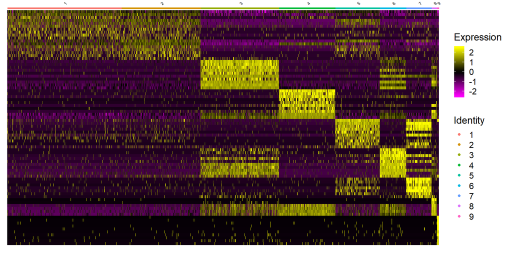

```r
# select top 10 markers for each cluster.
top10 <- pbmc.markers %>% group_by(cluster) %>% top_n(n = 10, wt = avg_logFC)
# heatmap the top 10 markers for each cluster.
DoHeatmap(pbmc,
          features = top10$gene,
          raster = F,
          size = 2) +
  theme(axis.text.y = element_blank())
```

## 9. Identify the cell types

In this PBMC data, we can use the canonical markers to identify cell types and to mach the cell clusters.

| Cell Clusters | Gene Markers | Cell Types |  |
| --- | --- | --- | --- |
| 4 | MS4A1 | B |  |
| 7 | GNLY, NKG7 | NK |  |
| 3 | CD14, LYZ | CD14+ Mono |  |
| 1 | IL7R, CCR7 | Naive CD4+T |  |
| 8 | FCER1A, CST3 | DC |  |
| 6 | MS4A7, FCGR3A | FCGR3A+ Mono |  |
| 2 | IL7R, S100A4 | Memory CD4+ |  |
| 5 | CD8A | CD8+ T |  |
| 9 | PPBP | Platelet |  |

So we can plot the cell types labels on the each cluster

```r
pbmc[["cell_types"]] <- "undetermined"

pbmc@meta.data$cell_types[pbmc@meta.data$cell_labels == "1"] <- "Naive CD4+ T"
pbmc@meta.data$cell_types[pbmc@meta.data$cell_labels == "2"] <- "Memory CD4+"
pbmc@meta.data$cell_types[pbmc@meta.data$cell_labels == "3"] <- "CD14+ Mono"
pbmc@meta.data$cell_types[pbmc@meta.data$cell_labels == "4"] <- "B"
pbmc@meta.data$cell_types[pbmc@meta.data$cell_labels == "5"] <- "CD8+ T"
pbmc@meta.data$cell_types[pbmc@meta.data$cell_labels == "6"] <- "FCGR3A+ Mono"
pbmc@meta.data$cell_types[pbmc@meta.data$cell_labels == "7"] <- "NK"
pbmc@meta.data$cell_types[pbmc@meta.data$cell_labels == "8"] <- "DC"
pbmc@meta.data$cell_types[pbmc@meta.data$cell_labels == "9"] <- "Platelet"
```

### B and NK

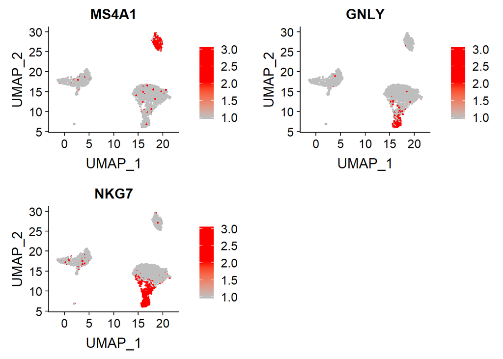

```r
# B, NK
FeaturePlot(pbmc,
            features = c("MS4A1", # B
                         "GNLY", "NKG7"), # NK
            cols = c("grey", "red", "red"),
            ncol = 2)
```

### CD14+Mono and Naive CD4+T

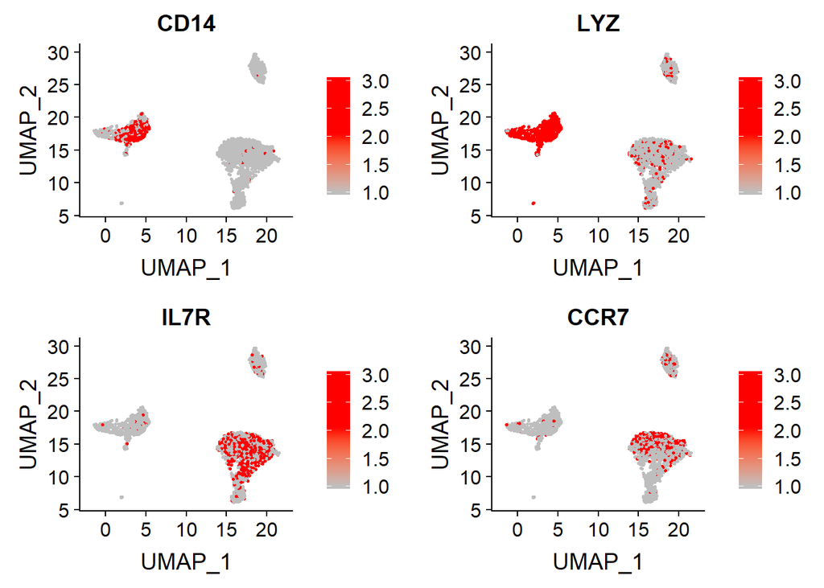

```r
# CD14+Mono, Naive CD4+T
FeaturePlot(pbmc,
            features = c("CD14", "LYZ", # CD14+Mono
                         "IL7R", "CCR7"), # Naive CD4+T
            cols = c("grey", "red", "red"),
            ncol = 2)
```

### DC, FCGR3A+ Mono

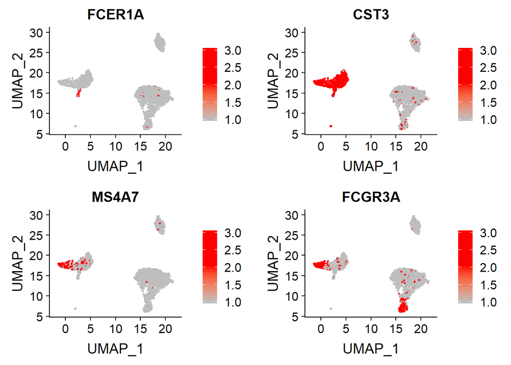

```r
# DC, FCGR3A+ Mono
FeaturePlot(pbmc,
            features = c("FCER1A", "CST3", # DC
                         "MS4A7", "FCGR3A"), # FCGR3A+ Mono
            cols = c("grey", "red", "red"),
            ncol = 2)
```

### Memory CD4+, CD8+T, Platelet

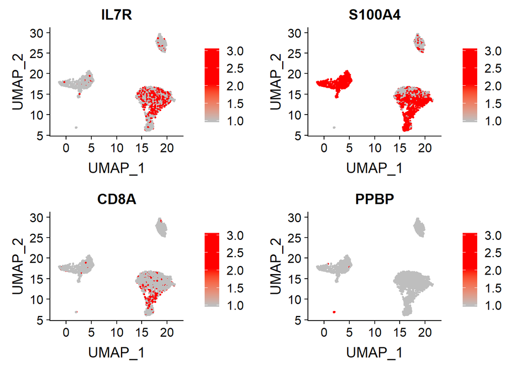

```r
# Memory CD4+, CD8+ T, Platelet
FeaturePlot(pbmc,
            features = c("IL7R", "S100A4", # Memory CD4+
                         "CD8A", # CD8+T
                         "PPBP"), # Platelet
            cols = c("grey", "red", "red"),
            ncol = 2)
```

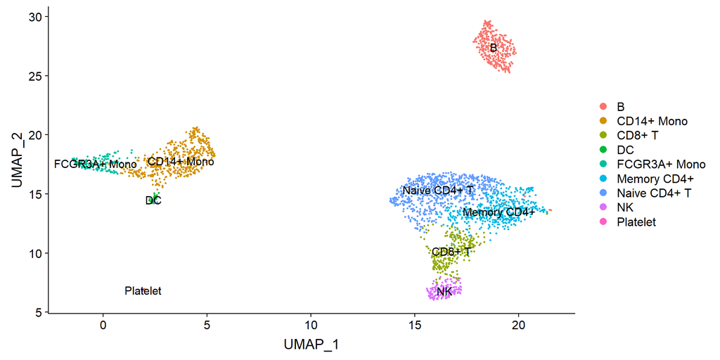

```r
DimPlot(pbmc,
        reduction = "umap",
        label = T,
        group.by = "cell_types")
```

## 10. Enrichment Analysis

### GO enrichment

We have to transform the gene `SYMBOL` to `ENTREZID` before enrichment.

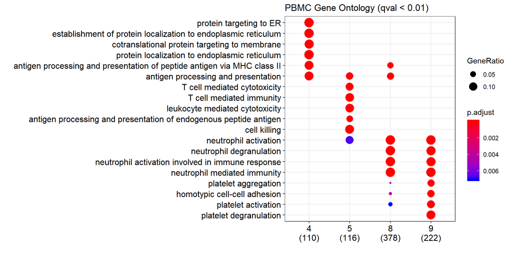

```r
# At first, we select the some cluster to do GO analysis
# 4:B, 5:CD8+ T, 8:DC, 9:Platet
marker <- pbmc.markers[as.character(pbmc.markers$cluster) %in% c("4", "5", "8", "9"), ]
marker$cluster <- as.character(marker$cluster)
marker <-  split(marker$gene, marker$cluster)
# we can select the top 20 genes.
top20 <- pbmc.markers %>% group_by(cluster) %>% top_n(n = 100, wt = avg_logFC)
top20 <- split(top20$gene, top20$cluster)

entrezid <-  lapply(marker, function(gr) as.numeric(bitr(gr, fromType = "SYMBOL", toType = "ENTREZID", OrgDb = "org.Hs.eg.db")$ENTREZID))

# PBMC GO
pvalueCutoff = 0.01
qvalueCutoff = 0.01
pbmc_go <- compareCluster(entrezid,
                          OrgDb='org.Hs.eg.db',
                          fun='enrichGO',
                          pvalueCutoff = pvalueCutoff,
                          qvalueCutoff = qvalueCutoff,
                          ont = "BP",
                          readable=T)
# plot the go
dotplot(pbmc_go,
        title = paste0("PBMC Gene Ontology (qval < ", qvalueCutoff, ")"))
```

```r
# view the go table data
go_table = pbmc_go@compareClusterResult
datatable(go_table, filter="top", options=list(pageLength = 10))
```

|  | Cluster | ID | Description | GeneRatio | BgRatio | pvalue | p.adjust | qvalue | geneID | Count |
| --- | --- | --- | --- | --- | --- | --- | --- | --- | --- | --- |
| 1 | 4 | GO:0045047 | protein targeting to ER | 15/110 | 117/18493 | 2.94551658311239e-16 | 4.51067416801529e-13 | 4.03040581104727e-13 | RPL18A/RPS23/RPS11/RPS5/RPL13A/RPS8/RPL15/RPL8/RPL18/RPS27/RPL10A/RPSA/RPS21/SEC62/SPCS2 | 15 |
| 2 | 4 | GO:0072599 | establishment of protein localization to endoplasmic reticulum | 15/110 | 121/18493 | 4.94049744579988e-16 | 4.51067416801529e-13 | 4.03040581104727e-13 | RPL18A/RPS23/RPS11/RPS5/RPL13A/RPS8/RPL15/RPL8/RPL18/RPS27/RPL10A/RPSA/RPS21/SEC62/SPCS2 | 15 |
| 3 | 4 | GO:0006613 | cotranslational protein targeting to membrane | 14/110 | 109/18493 | 2.9702476760502e-15 | 1.80789075215589e-12 | 1.6153978589045e-12 | RPL18A/RPS23/RPS11/RPS5/RPL13A/RPS8/RPL15/RPL8/RPL18/RPS27/RPL10A/RPSA/RPS21/SEC62 | 14 |
| 4 | 4 | GO:0070972 | protein localization to endoplasmic reticulum | 15/110 | 146/18493 | 8.59611597097026e-15 | 3.92412694074792e-12 | 3.50631046184313e-12 | RPL18A/RPS23/RPS11/RPS5/RPL13A/RPS8/RPL15/RPL8/RPL18/RPS27/RPL10A/RPSA/RPS21/SEC62/SPCS2 | 15 |
| 5 | 4 | GO:0002495 | antigen processing and presentation of peptide antigen via MHC class II | 13/110 | 101/18493 | 2.97386340395269e-14 | 8.86365673812733e-12 | 7.91991003867952e-12 | HLA-DQA1/HLA-DQB1/CD74/HLA-DRA/HLA-DPB1/HLA-DRB1/HLA-DPA1/HLA-DQA2/HLA-DRB5/HLA-DOB/HLA-DMA/HLA-DMB/MARCH1 | 13 |
| 6 | 4 | GO:0002504 | antigen processing and presentation of peptide or polysaccharide antigen via MHC class II | 13/110 | 102/18493 | 3.39160014094744e-14 | 8.86365673812733e-12 | 7.91991003867952e-12 | HLA-DQA1/HLA-DQB1/CD74/HLA-DRA/HLA-DPB1/HLA-DRB1/HLA-DPA1/HLA-DQA2/HLA-DRB5/HLA-DOB/HLA-DMA/HLA-DMB/MARCH1 | 13 |
| 7 | 4 | GO:0006413 | translational initiation | 16/110 | 194/18493 | 3.3978968875625e-14 | 8.86365673812733e-12 | 7.91991003867952e-12 | BANK1/RPL18A/RPS23/RPS11/RPS5/RPL13A/RPS8/RPL15/RPL8/RPL18/RPS27/RPL10A/RPSA/RPS21/EIF4A2/EIF4G2 | 16 |
| 8 | 4 | GO:0006614 | SRP-dependent cotranslational protein targeting to membrane | 13/110 | 105/18493 | 4.98899263785429e-14 | 1.13873756959024e-11 | 1.01749191956239e-11 | RPL18A/RPS23/RPS11/RPS5/RPL13A/RPS8/RPL15/RPL8/RPL18/RPS27/RPL10A/RPSA/RPS21 | 13 |
| 9 | 4 | GO:0000184 | nuclear-transcribed mRNA catabolic process, nonsense-mediated decay | 13/110 | 120/18493 | 2.90807467810176e-13 | 5.90016040245978e-11 | 5.27194824685114e-11 | RPL18A/RPS23/RPS11/RPS5/RPL13A/RPS8/RPL15/RPL8/RPL18/RPS27/RPL10A/RPSA/RPS21 | 13 |
| 10 | 4 | GO:0019886 | antigen processing and presentation of exogenous peptide antigen via MHC class II | 12/110 | 98/18493 | 5.62748572996455e-13 | 1.02757889429153e-10 | 9.18168724362636e-11 | HLA-DQA1/HLA-DQB1/CD74/HLA-DRA/HLA-DPB1/HLA-DRB1/HLA-DPA1/HLA-DQA2/HLA-DRB5/HLA-DOB/HLA-DMA/HLA-DMB | 12 |

[output cut: 403 more lines]

```r
# we can save the GO table as the .html file
# datatable(go_table, filter="top", options=list(pageLength = 10)) %>% saveWidget("pbmc_go.html")
```

### PA enrichment

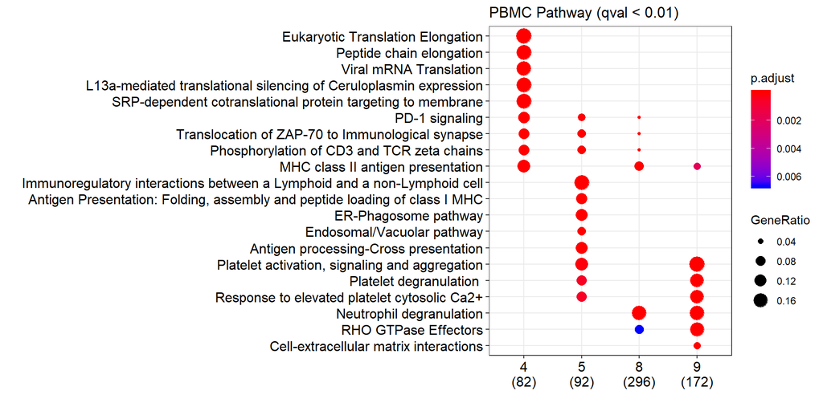

```r
# And then we can do the pathway analysis
pbmc_pa<- compareCluster(entrezid,
                         organism = "human",
                         fun='enrichPathway',
                         pvalueCutoff = pvalueCutoff,
                         qvalueCutoff = qvalueCutoff,
                         readable=T)
# plot the PA
dotplot(pbmc_pa,
        title = paste0("PBMC Pathway (qval < ", qvalueCutoff, ")"))
```

```r
# pa_table = pbmc_pa@compareClusterResult
```